# NOAA Storm Data Analysis

Here I analyzed the consequences of different types of events on population health and economic loss to guide the preparation towards severe weather.

Note: the generated .html file can be viewed at: https://yafangchen.github.io/05_RR_Project2_Sep2014/Project2.html

## Data Processing

The data was loaded and saved in the working directory and then read with the read.csv command.

```r
library(ggplot2)
library(reshape2)
if(!file.exists("repdata-data-StormData.csv")){
        unzip("repdata-data-StormData.csv.bz2")
}
data <- read.csv("repdata-data-StormData.csv")
dim(data)
```

```
## [1] 902297     37
```

### Subset relevant data

The next step is to subset variables that are relevant to the questions. “FATALITIES” and “INJURIES” will be used for analyzing how the events harm population health, while “PROPDMG”, “PROPDMGEXP”, “CROPDMG” and “CROPDMGEXP” will be needed to analyze the economic damage. “PROPDMGEXP” and “CROPDMGEXP” are the magnitude values for “PROPDMG” and “CROPDMG”, respectively.

```r
both <- data[,c("EVTYPE","FATALITIES","INJURIES","PROPDMG","PROPDMGEXP","CROPDMG","CROPDMGEXP")]
```

### Incorporate the magnitude value to calculate real property (PROP) damage

```r
both$PROPDMGEXP <- tolower(both$PROPDMGEXP)
unique(both$PROPDMGEXP)
```

```
##  [1] "k" "m" ""  "b" "+" "0" "5" "6" "?" "4" "2" "3" "h" "7" "-" "1" "8"
```

```r
both$PROPDMGEXP[both$PROPDMGEXP %in% c("+","0","?","-","")] <- 0
both$PROPDMGEXP[both$PROPDMGEXP == "k"] <- 3
both$PROPDMGEXP[both$PROPDMGEXP == "m"] <- 6
both$PROPDMGEXP[both$PROPDMGEXP == "h"] <- 2
both$PROPDMGEXP[both$PROPDMGEXP == "b"] <- 9
unique(both$PROPDMGEXP)
```

```
##  [1] "3" "6" "0" "9" "5" "4" "2" "7" "1" "8"
```

```r
both$PROPDMGEXP <- as.numeric(both$PROPDMGEXP)
both$PROP <- both$PROPDMG * 10^(both$PROPDMGEXP)
```

### Incorporate the magnitude value to calculate real CROP damage

```r
both$CROPDMGEXP <- tolower(both$CROPDMGEXP)
unique(both$CROPDMGEXP)
```

```
## [1] ""  "m" "k" "b" "?" "0" "2"
```

```r
both$CROPDMGEXP[both$CROPDMGEXP %in% c("","?")] <- 0
both$CROPDMGEXP[both$CROPDMGEXP == "m"] <- 6
both$CROPDMGEXP[both$CROPDMGEXP == "k"] <- 3
both$CROPDMGEXP[both$CROPDMGEXP == "b"] <- 9
unique(both$CROPDMGEXP)
```

```
## [1] "0" "6" "3" "9" "2"
```

```r
both$CROPDMGEXP <- as.numeric(both$CROPDMGEXP)
both$CROP <- both$CROPDMG * 10^(both$CROPDMGEXP)
```

### Clean up “EVTYPE”

Upon aggregating the data and subsetting only records with positive values for population health threat or economic loss, values of “EVTYPE” was found to be messy. Thus the “EVTYPE” feature was cleaned up in the next step:

```r
aggboth <- aggregate(cbind(FATALITIES,INJURIES,PROP,CROP)~EVTYPE,both,sum)
posaggboth <- aggboth[aggboth$FATALITIES>0|aggboth$INJURIES>0|aggboth$PROP>0|aggboth$CROP>0,]
posaggboth$EVTYPE <- tolower(posaggboth$EVTYPE)
##unique(posaggboth$EVTYPE)
posaggboth$EVTYPE[grep("avalan",posaggboth$EVTYPE)] = "avalanche"
posaggboth$EVTYPE[grep("snow",posaggboth$EVTYPE)] = "snow"
posaggboth$EVTYPE[grep("heat",posaggboth$EVTYPE)] = "heat"
posaggboth$EVTYPE[grep("cold",posaggboth$EVTYPE)] = "cold"
posaggboth$EVTYPE[grep("drought|dry",posaggboth$EVTYPE)] = "drought"
posaggboth$EVTYPE[grep("flood",posaggboth$EVTYPE)] = "flood"
posaggboth$EVTYPE[grep("rain",posaggboth$EVTYPE)] = "rain"
posaggboth$EVTYPE[grep("wind",posaggboth$EVTYPE)] = "wind"
posaggboth$EVTYPE[grep("hurricane",posaggboth$EVTYPE)] = "hurricane"
posaggboth$EVTYPE[grep("ic[ey]",posaggboth$EVTYPE)] = "ice"
posaggboth$EVTYPE[grep("light[n ]ing",posaggboth$EVTYPE)] = "lightning"
posaggboth$EVTYPE[grep("winter",posaggboth$EVTYPE)] = "winter"
posaggboth$EVTYPE[grep("thunderstorm",posaggboth$EVTYPE)] = "thunderstorm"
posaggboth$EVTYPE[grep("tornado",posaggboth$EVTYPE)] = "tornado"
posaggboth$EVTYPE[grep("wild(.*)fire",posaggboth$EVTYPE)] = "wildfire"
posaggboth$EVTYPE[grep("free",posaggboth$EVTYPE)] = "freeze"
posaggboth$EVTYPE[grep("[^r]storm|^storm",posaggboth$EVTYPE)] = "storm"
posaggboth$EVTYPE[grep("mud",posaggboth$EVTYPE)] = "mudslide"
posaggboth$EVTYPE[grep("hail",posaggboth$EVTYPE)] = "hail"
```

## Results

### What events are the most harmful towards population health?

```r
health <- posaggboth[posaggboth$FATALITIES>0|posaggboth$INJURIES>0,c("EVTYPE","FATALITIES","INJURIES")]
health$tot <- health$FATALITIES + health$INJURIES
healthTop10 <- health[order(health$tot,decreasing=TRUE)[1:10],]
healthTop10
```

```
##        EVTYPE FATALITIES INJURIES   tot
## 834   tornado       5633    91346 96979
## 130      heat       1903     6525  8428
## 856      wind        504     6957  7461
## 170     flood        470     6789  7259
## 464 lightning        816     5230  6046
## 275      heat        937     2100  3037
## 153     flood        978     1777  2755
## 427       ice         89     1975  2064
## 760      wind        133     1488  1621
## 972    winter        206     1321  1527
```

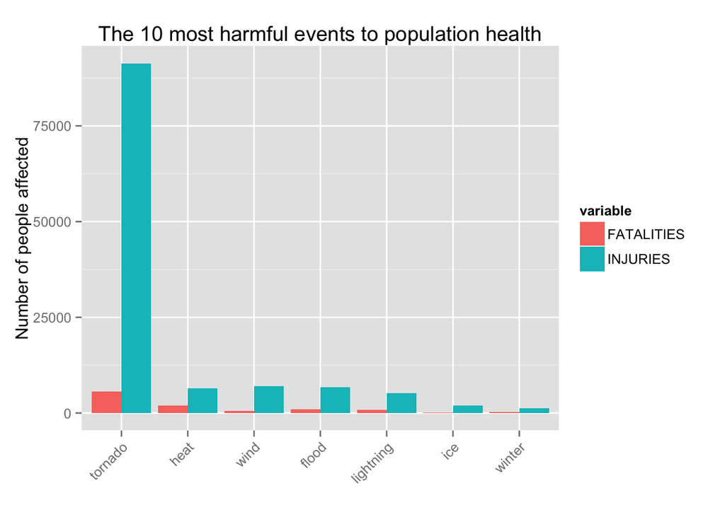

```r
MeltHealthTop10 <- melt(healthTop10[,1:3], id.vars=c("EVTYPE"))
MeltHealthTop10$EVTYPE <- factor(MeltHealthTop10$EVTYPE,levels=unique(MeltHealthTop10$EVTYPE))
ggplot(MeltHealthTop10,aes(x=EVTYPE,y=value,fill=variable)) +
        geom_bar(position="dodge",stat="identity",binwidth=1) +
        ggtitle("The 10 most harmful events to population health") +
        labs(x="",y="Number of people affected") +
        theme(axis.text.x=element_text(angle=45,hjust=1))
```

As shown above, **tornado** is the most harmful events to population health. The casuality (fatality plus injury) of tornado is way higher than that of other events.

### What events cause the most economic damage?

```r
options(scipen=999)
Econ <- posaggboth[posaggboth$PROP>0|posaggboth$CROP>0,c("EVTYPE","PROP","CROP")]
Econ$totDMG <- Econ$PROP + Econ$CROP
Econtop10 <- Econ[order(Econ$totDMG,decreasing=TRUE)[1:10],]
Econtop10
```

```
##        EVTYPE         PROP        CROP       totDMG
## 170     flood 144657709807  5661968450 150319678257
## 411 hurricane  69305840000  2607872800  71913712800
## 834   tornado  56947380676   414953270  57362333946
## 670     storm  43323536000        5000  43323541000
## 244      hail  15735267513  3025954473  18761221986
## 153     flood  16822673978  1421317100  18243991078
## 95    drought   1046106000 13972566000  15018672000
## 402 hurricane  11868319010  2741910000  14610229010
## 590     flood   5118945500  5029459000  10148404500
## 427       ice   3944927860  5022113500   8967041360
```

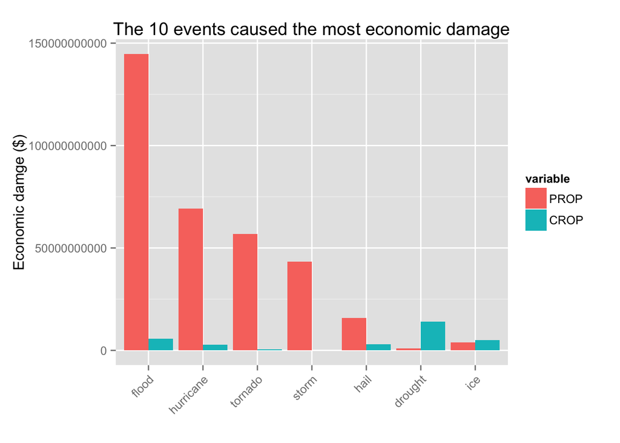

```r
MeltEcontop10 <- melt(Econtop10[,1:3], id.vars=c("EVTYPE"))
MeltEcontop10$EVTYPE <- factor(MeltEcontop10$EVTYPE,levels=unique(MeltEcontop10$EVTYPE))
ggplot(MeltEcontop10,aes(x=EVTYPE,y=value,fill=variable)) +
        geom_bar(position="dodge",stat="identity",binwidth=1) +
        ggtitle("The 10 events caused the most economic damage") +
        labs(x="",y="Economic damge ($)") +
        theme(axis.text.x=element_text(angle=45,hjust=1))
```

As shown above, **flood** is the event that cause the most economic damage, followed by events such as **hurricane, tornado, storm and hail**.